# Empathy in Real vs. Synthetic Clinician Comments

## 2 Data

6600 Reddit posts were used, each paired with its real clinician comment(s) and synthetic comments from 3 models x 3 prompting methods. 137278 comments were classified in total: 8625 real and 128653 synthetic (14295 per model/method group on average). Predicted empathy comes from the same three fine-tuned RoBERTa bi-encoder classifiers used in pilot 1 (Emotional Reactions, Interpretations, Explorations; see `../2_training`), each producing an ordinal label: 0 = none, 1 = weak, 2 = strong.

## 3 Mean predicted empathy by group

Empathy labels are ordinal (0 = none, 1 = weak, 2 = strong). The means shown below implicitly treat the labels as equally spaced, and are shown only as a quick, monotonic summary (Fig. 1). The actual label distribution (the ordinal-honest view) is plotted underneath it as proportions per group (Fig. 2).

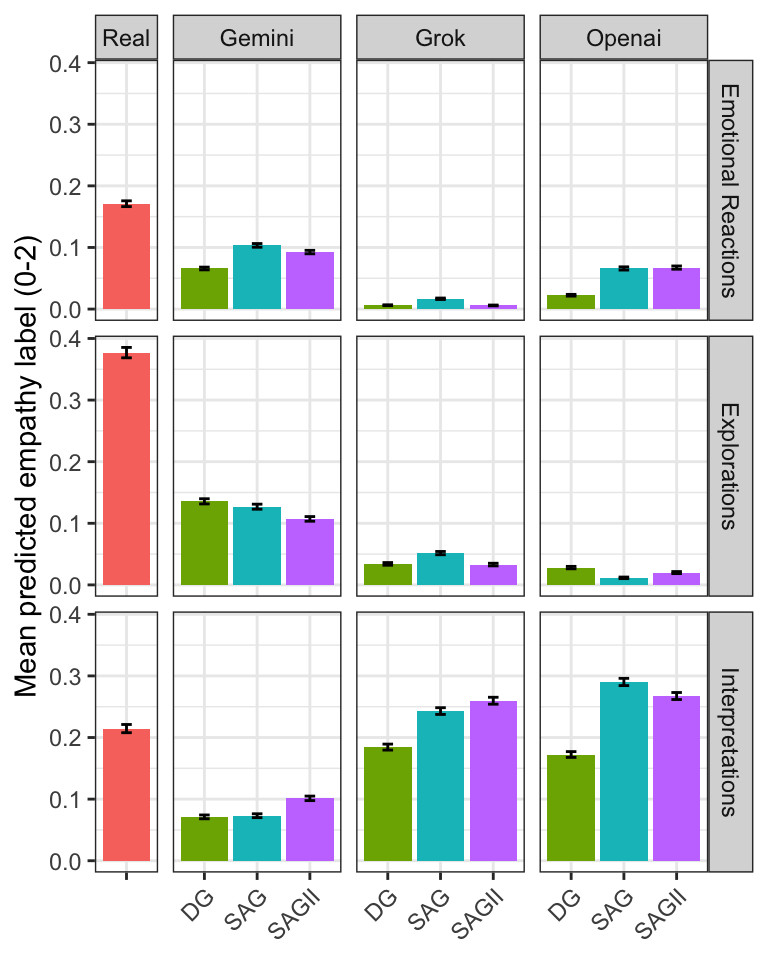

Figure 1: Average predicted empathy per population.

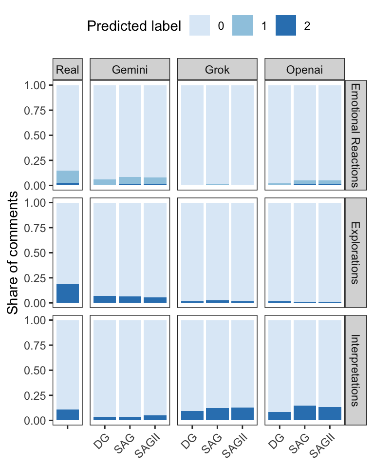

Figure 2: Stacked predicted label proportions per population.

Table 1: Predicted label proportions by group (same data as Fig. 2, as a table)—useful for spotting cells too sparse to trust, e.g. where P(label=1) is 0.

| Mechanism | Model | Method | n | P(label=0) | P(label=1) | P(label=2) |
| --- | --- | --- | --- | --- | --- | --- |
| Emotional Reactions | Real |  | 8625 | 0.853 | 0.123 | 0.024 |
|  | Gemini | DG | 14301 | 0.939 | 0.056 | 0.005 |
|  |  | SAG | 14288 | 0.914 | 0.068 | 0.018 |
|  |  | SAGII | 14300 | 0.921 | 0.065 | 0.014 |
|  | Grok | DG | 14258 | 0.994 | 0.006 | 0.000 |
|  |  | SAG | 14300 | 0.985 | 0.013 | 0.002 |
|  |  | SAGII | 14300 | 0.994 | 0.005 | 0.000 |
|  | Openai | DG | 14302 | 0.981 | 0.016 | 0.003 |
|  |  | SAG | 14302 | 0.951 | 0.032 | 0.017 |
|  |  | SAGII | 14302 | 0.950 | 0.033 | 0.017 |
| Explorations | Real |  | 8625 | 0.811 | 0.000 | 0.189 |
|  | Gemini | DG | 14301 | 0.932 | 0.000 | 0.068 |
|  |  | SAG | 14288 | 0.937 | 0.000 | 0.063 |
|  |  | SAGII | 14300 | 0.946 | 0.000 | 0.054 |
|  | Grok | DG | 14258 | 0.983 | 0.000 | 0.017 |
|  |  | SAG | 14300 | 0.974 | 0.000 | 0.026 |
|  |  | SAGII | 14300 | 0.983 | 0.000 | 0.017 |
|  | Openai | DG | 14302 | 0.986 | 0.000 | 0.014 |
|  |  | SAG | 14302 | 0.994 | 0.000 | 0.006 |
|  |  | SAGII | 14302 | 0.990 | 0.000 | 0.010 |
| Interpretations | Real |  | 8625 | 0.893 | 0.000 | 0.107 |
|  | Gemini | DG | 14301 | 0.964 | 0.000 | 0.036 |
|  |  | SAG | 14288 | 0.963 | 0.000 | 0.037 |
|  |  | SAGII | 14300 | 0.949 | 0.000 | 0.051 |
|  | Grok | DG | 14258 | 0.908 | 0.000 | 0.092 |
|  |  | SAG | 14300 | 0.879 | 0.000 | 0.121 |
|  |  | SAGII | 14300 | 0.870 | 0.000 | 0.130 |
|  | Openai | DG | 14302 | 0.914 | 0.000 | 0.086 |
|  |  | SAG | 14302 | 0.855 | 0.000 | 0.145 |
|  |  | SAGII | 14302 | 0.866 | 0.000 | 0.134 |

## 4 Real vs. synthetic (Mann-Whitney U, Benjamini-Hochberg adjusted)

Table 2 shows that all real-vs-synthetic contrasts are significant, such that real ones score significantly higher. Notable exceptions, where the synthetic ones score higher are marked in red.

Table 2: Mann-Whitney U test.

| Mechanism | Model | Method | Mean (real) | Mean (synthetic) | p | p (BH-adj.) | Rank-biserial r |
| --- | --- | --- | --- | --- | --- | --- | --- |
| Emotional Reactions | Gemini | DG | 0.171 | 0.066 | 0.0000 | 0.0000 | 0.087 |
|  |  | SAG | 0.171 | 0.103 | 0.0000 | 0.0000 | 0.060 |
|  |  | SAGII | 0.171 | 0.093 | 0.0000 | 0.0000 | 0.068 |
|  | Grok | DG | 0.171 | 0.006 | 0.0000 | 0.0000 | 0.141 |
|  |  | SAG | 0.171 | 0.017 | 0.0000 | 0.0000 | 0.132 |
|  |  | SAGII | 0.171 | 0.006 | 0.0000 | 0.0000 | 0.141 |
|  | Openai | DG | 0.171 | 0.022 | 0.0000 | 0.0000 | 0.127 |
|  |  | SAG | 0.171 | 0.066 | 0.0000 | 0.0000 | 0.097 |
|  |  | SAGII | 0.171 | 0.067 | 0.0000 | 0.0000 | 0.096 |
| Explorations | Gemini | DG | 0.377 | 0.136 | 0.0000 | 0.0000 | 0.121 |
|  |  | SAG | 0.377 | 0.127 | 0.0000 | 0.0000 | 0.125 |
|  |  | SAGII | 0.377 | 0.107 | 0.0000 | 0.0000 | 0.135 |
|  | Grok | DG | 0.377 | 0.034 | 0.0000 | 0.0000 | 0.171 |
|  |  | SAG | 0.377 | 0.052 | 0.0000 | 0.0000 | 0.163 |
|  |  | SAGII | 0.377 | 0.033 | 0.0000 | 0.0000 | 0.172 |
|  | Openai | DG | 0.377 | 0.028 | 0.0000 | 0.0000 | 0.174 |
|  |  | SAG | 0.377 | 0.011 | 0.0000 | 0.0000 | 0.183 |
|  |  | SAGII | 0.377 | 0.020 | 0.0000 | 0.0000 | 0.179 |
| Interpretations | Gemini | DG | 0.214 | 0.071 | 0.0000 | 0.0000 | 0.072 |
|  |  | SAG | 0.214 | 0.073 | 0.0000 | 0.0000 | 0.071 |
|  |  | SAGII | 0.214 | 0.101 | 0.0000 | 0.0000 | 0.057 |
|  | Grok | DG | 0.214 | 0.184 | 0.0002 | 0.0002 | 0.015 |
|  |  | SAG | 0.214 | 0.243 | 0.0011 | 0.0011 | -0.014 |
|  |  | SAGII | 0.214 | 0.260 | 0.0000 | 0.0000 | -0.023 |
|  | Openai | DG | 0.214 | 0.172 | 0.0000 | 0.0000 | 0.021 |
|  |  | SAG | 0.214 | 0.290 | 0.0000 | 0.0000 | -0.038 |
|  |  | SAGII | 0.214 | 0.267 | 0.0000 | 0.0000 | -0.026 |

## 5 Mixed-effects models

The Mann-Whitney tests above treat every comment as independent, but they aren’t: several synthetic comments (and sometimes several real ones) come from the *same* Reddit thread, so they share whatever makes that particular topic more or less emotionally charged or explorable. To account for that, we run two mixed-effects models per mechanism:

- **A - omnibus** (`label ~ group + log(length) + (1|post_id)`, all 137278 comments): tests whether the 10-level group factor (real + 9 model/method combinations) matters at all.
- **B - model × method** (`label ~ model * method + log(length) + (1|post_id)`, synthetic comments only - “real” has no model/method to cross): tests the model main effect, the method main effect, and whether they interact.

**Emotional Reactions** uses all 3 empathy levels, so it’s fit as a cumulative link mixed model (`ordinal::clmm`). **Interpretations** and **Explorations** never predict label 1 anywhere in this data (0 occurrences out of 137278 comments, checked directly), so a 3-level ordinal model would be degenerate for them—they’re fit instead as binomial mixed models (`lme4::glmer`) on P(label = 2).

Table 3: Convergence status for each fitted model.

| Mechanism | Model | Type | Converged | Note |
| --- | --- | --- | --- | --- |
| Emotional Reactions | A_group_omnibus | clmm | FALSE | max\|grad\| = 0.0147 (didn’t fully settle) |
| Emotional Reactions | B_model_x_method | clmm | FALSE | max\|grad\| = 280, Hessian is not usable - fit did not converge, results not reliable |
| Interpretations | A_group_omnibus | glmer | TRUE | NA |
| Interpretations | B_model_x_method | glmer | TRUE | NA |
| Explorations | A_group_omnibus | glmer | TRUE | NA |
| Explorations | B_model_x_method | glmer | TRUE | NA |

**Emotional Reactions’s Model A (omnibus test, vs.-real contrasts) had a small residual gradient** (max|grad| = 0.0147 (didn’t fully settle)) but its estimates are usable and reported below as directionally informative. **Model B (the model x method interaction) failed to converge outright** (max|grad| = 280, Hessian is not usable - fit did not converge, results not reliable) - its Hessian isn’t usable, so no valid significance test or simple-effects contrasts exist for it, and none are reported below; this is plausibly related to how sparse label 2 is for the thinnest group (grok_dg: 2/14258 at label 2). IP and EX converged cleanly throughout.

Table 4: Model A: omnibus test for group (real + 9 model/method combinations), replacing Kruskal-Wallis.

| Mechanism | Chi-sq | df | p |
| --- | --- | --- | --- |
| Emotional Reactions | 3996.9 | 9 | 0 |
| Interpretations | 2603.3 | 9 | 0 |
| Explorations | 4464.7 | 9 | 0 |

The group effect is significant for all 3 mechanisms (Table 4). Comment length (log-transformed) is included as a covariate in both models and is a significant predictor everywhere (Model A: all 3 $p < 0.001$), but not in the same direction: Emotional Reactions, Interpretations score higher with more words, while Explorations scores lower with more words—plausibly because exploratory, question-asking replies tend to be short follow-ups rather than long ones.

Table 5: Model A: each (model, method) group vs. real (OR below 1 = lower odds of higher empathy than real; rows with OR above 1 shaded).

| Mechanism | Group | Odds ratio | OR 95% LCL | OR 95% UCL | p (BH-adj.) |
| --- | --- | --- | --- | --- | --- |
| Emotional Reactions | gemini_dg | 0.279 | 0.251 | 0.311 | 0 |
| Emotional Reactions | openai_dg | 0.052 | 0.045 | 0.060 | 0 |
| Emotional Reactions | grok_dg | 0.021 | 0.017 | 0.027 | 0 |
| Emotional Reactions | gemini_sag | 0.431 | 0.391 | 0.476 | 0 |
| Emotional Reactions | openai_sag | 0.128 | 0.114 | 0.144 | 0 |
| Emotional Reactions | grok_sag | 0.048 | 0.041 | 0.056 | 0 |
| Emotional Reactions | gemini_sagii | 0.359 | 0.325 | 0.396 | 0 |
| Emotional Reactions | openai_sagii | 0.133 | 0.118 | 0.149 | 0 |
| Emotional Reactions | grok_sagii | 0.016 | 0.013 | 0.021 | 0 |
| Interpretations | gemini_dg | 0.531 | 0.464 | 0.606 | 0 |
| Interpretations | openai_dg | 0.604 | 0.544 | 0.671 | 0 |
| Interpretations | grok_dg | 2.062 | 1.832 | 2.320 | 0 |
| Interpretations | gemini_sag | 0.475 | 0.416 | 0.541 | 0 |
| Interpretations | openai_sag | 0.648 | 0.586 | 0.716 | 0 |
| Interpretations | grok_sag | 2.041 | 1.830 | 2.277 | 0 |
| Interpretations | gemini_sagii | 0.594 | 0.526 | 0.670 | 0 |
| Interpretations | openai_sagii | 0.578 | 0.523 | 0.639 | 0 |
| Interpretations | grok_sagii | 2.453 | 2.197 | 2.739 | 0 |
| Explorations | gemini_dg | 0.195 | 0.177 | 0.216 | 0 |
| Explorations | openai_dg | 0.036 | 0.031 | 0.043 | 0 |
| Explorations | grok_dg | 0.036 | 0.031 | 0.042 | 0 |
| Explorations | gemini_sag | 0.185 | 0.167 | 0.205 | 0 |
| Explorations | openai_sag | 0.017 | 0.013 | 0.022 | 0 |
| Explorations | grok_sag | 0.063 | 0.055 | 0.071 | 0 |
| Explorations | gemini_sagii | 0.155 | 0.139 | 0.173 | 0 |
| Explorations | openai_sagii | 0.030 | 0.025 | 0.037 | 0 |
| Explorations | grok_sagii | 0.037 | 0.032 | 0.043 | 0 |

Table 5: real scores significantly higher than every synthetic group for Emotional Reactions, Explorations; Interpretations is the exception—grok_dg, grok_sag, grok_sagii score significantly *higher* than real.

This isn’t quite what the raw Mann-Whitney table shows: refitting without `log(length)` flips the direction for grok_dg, openai_sag, openai_sagii (3 groups), reproducing the raw pattern for those groups almost exactly—so this looks like a length confound: comment length differs systematically across models and strongly predicts this label, so part of the length-adjusted picture for these groups is attributable to comment length rather than the model/method itself.

Table 6: Model B: model, method, and model x method tests (synthetic comments only), replacing the pooled by-method/by-model comparisons.

| Mechanism | Term | Chi-sq | df | p |
| --- | --- | --- | --- | --- |
| Emotional Reactions | model | NA | NA | NA |
| Emotional Reactions | method | NA | NA | NA |
| Emotional Reactions | model:method | NA | NA | NA |
| Interpretations | model | 2742.7 | 2 | 0.0000 |
| Interpretations | method | 11.3 | 2 | 0.0035 |
| Interpretations | model:method | 47.3 | 4 | 0.0000 |
| Explorations | model | 1378.5 | 2 | 0.0000 |
| Explorations | method | 40.9 | 2 | 0.0000 |
| Explorations | model:method | 101.3 | 4 | 0.0000 |

The model x method interaction is significant for all 2 mechanisms it could be tested for—not estimable for Emotional Reactions, whose Model B fit failed to converge, i.e. for those mechanisms the effect of a prompting method genuinely depends on which model generated it. Both main effects (model and method) are significant for every mechanism they could be tested for, on top of the interaction. Emotional Reactions’s model and method main effects aren’t estimable here—its Model B fit failed to converge, so there’s no valid test for any term in it beyond what’s noted above.

Since the interaction is significant for at least one mechanism, pooled main-effect means (averaged over the other factor) would be misleading there - e.g. a model’s “average” effect can look muted if it does well with one method and poorly with another. So instead, two sets of simple-effects contrasts throughout: models compared within each method, and methods compared within each model. Emotional Reactions is omitted from both tables below—its Model B fit failed to converge, so there are no valid contrasts to report.

Table 7: Model B: pairwise model contrasts within each method.

| Mechanism | Method | Contrast | Odds ratio | OR 95% LCL | OR 95% UCL | p (BH-adj.) |
| --- | --- | --- | --- | --- | --- | --- |
| Interpretations | dg | gemini / openai | 1.202 | 1.059 | 1.364 | 0.0051 |
| Interpretations | dg | gemini / grok | 0.237 | 0.212 | 0.265 | 0.0000 |
| Interpretations | dg | openai / grok | 0.197 | 0.176 | 0.221 | 0.0000 |
| Interpretations | sag | gemini / openai | 1.116 | 0.980 | 1.271 | 0.1026 |
| Interpretations | sag | gemini / grok | 0.228 | 0.204 | 0.254 | 0.0000 |
| Interpretations | sag | openai / grok | 0.204 | 0.183 | 0.227 | 0.0000 |
| Interpretations | sagii | gemini / openai | 1.498 | 1.333 | 1.684 | 0.0000 |
| Interpretations | sagii | gemini / grok | 0.218 | 0.198 | 0.241 | 0.0000 |
| Interpretations | sagii | openai / grok | 0.146 | 0.130 | 0.163 | 0.0000 |
| Explorations | dg | gemini / openai | 3.478 | 2.916 | 4.147 | 0.0000 |
| Explorations | dg | gemini / grok | 7.986 | 6.801 | 9.377 | 0.0000 |
| Explorations | dg | openai / grok | 2.296 | 1.846 | 2.857 | 0.0000 |
| Explorations | sag | gemini / openai | 3.827 | 2.901 | 5.047 | 0.0000 |
| Explorations | sag | gemini / grok | 3.327 | 2.892 | 3.827 | 0.0000 |
| Explorations | sag | openai / grok | 0.869 | 0.650 | 1.163 | 0.3455 |
| Explorations | sagii | gemini / openai | 1.933 | 1.537 | 2.430 | 0.0000 |
| Explorations | sagii | gemini / grok | 5.782 | 4.895 | 6.829 | 0.0000 |
| Explorations | sagii | openai / grok | 2.992 | 2.290 | 3.910 | 0.0000 |

Table 8: Model B: pairwise method contrasts within each model.

| Mechanism | Model | Contrast | Odds ratio | OR 95% LCL | OR 95% UCL | p (BH-adj.) |
| --- | --- | --- | --- | --- | --- | --- |
| Interpretations | gemini | dg / sag | 1.161 | 1.018 | 1.323 | 0.0390 |
| Interpretations | gemini | dg / sagii | 0.971 | 0.858 | 1.099 | 0.7001 |
| Interpretations | gemini | sag / sagii | 0.837 | 0.741 | 0.945 | 0.0084 |
| Interpretations | openai | dg / sag | 1.078 | 0.988 | 1.176 | 0.1174 |
| Interpretations | openai | dg / sagii | 1.211 | 1.109 | 1.322 | 0.0001 |
| Interpretations | openai | sag / sagii | 1.123 | 1.042 | 1.210 | 0.0051 |
| Interpretations | grok | dg / sag | 1.115 | 1.023 | 1.216 | 0.0223 |
| Interpretations | grok | dg / sagii | 0.894 | 0.821 | 0.973 | 0.0165 |
| Interpretations | grok | sag / sagii | 0.802 | 0.741 | 0.867 | 0.0000 |
| Explorations | gemini | dg / sag | 0.904 | 0.808 | 1.012 | 0.1106 |
| Explorations | gemini | dg / sagii | 0.974 | 0.864 | 1.097 | 0.7001 |
| Explorations | gemini | sag / sagii | 1.077 | 0.958 | 1.210 | 0.2590 |
| Explorations | openai | dg / sag | 0.995 | 0.745 | 1.329 | 0.9740 |
| Explorations | openai | dg / sagii | 0.541 | 0.422 | 0.694 | 0.0000 |
| Explorations | openai | sag / sagii | 0.544 | 0.408 | 0.724 | 0.0001 |
| Explorations | grok | dg / sag | 0.377 | 0.314 | 0.453 | 0.0000 |
| Explorations | grok | dg / sagii | 0.705 | 0.578 | 0.860 | 0.0014 |
| Explorations | grok | sag / sagii | 1.871 | 1.562 | 2.241 | 0.0000 |